# Ngôn ngữ Python

# Thư viện matplotlib

## Bài 1: Giới thiệu và cài đặt matplotlib

### Giới thiệu matplotlib

- **Matplotlib**: thư viện vẽ biểu đồ dựa trên NumPy.
- 🎯 Mục tiêu: đơn giản, chỉ vài dòng lệnh là có biểu đồ.
- 📊 Hỗ trợ nhiều loại biểu đồ: line, bar, histogram, scatter,...
- 🏗️ Interface:
  - `pyplot`: dễ dùng, phổ biến nhất.
  - OO API: linh hoạt, dùng cho project phức tạp.
  - `pylab`: kiểu MATLAB, đã ngừng phát triển.

👉 Thực tế chủ yếu dùng **`matplotlib.pyplot`**.

### Cài đặt: “pip install matplotlib”

## Bài 2: Vẽ biểu đồ đơn giản

### Ví dụ: vẽ biểu đồ y = x²

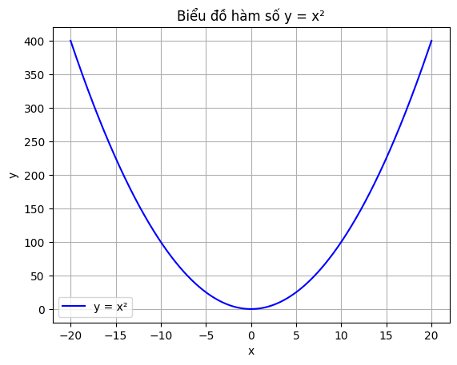

```python
import numpy as np  # thư viện numpy
import matplotlib.pyplot as plt  # thư viện matplotlib.pyplot

# Chia đoạn từ -20 đến 20 thành 1000 điểm
x = np.linspace(-20, 20, 1000)

# Tính y = x^2
y = x * x

# Vẽ biểu đồ
plt.plot(x, y, label="y = x²", color="blue")

# Thêm tiêu đề và nhãn
plt.title("Biểu đồ hàm số y = x²")
plt.xlabel("x")
plt.ylabel("y")

# Hiển thị lưới và chú thích
plt.grid(True)
plt.legend()

# Hiển thị biểu đồ
plt.show()
```

### Ví dụ: Vẽ biểu đồ hình sin

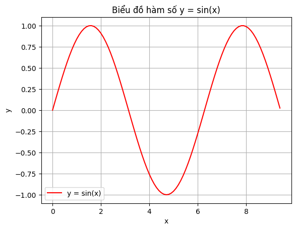

```python
import numpy as np  # thư viện numpy
import matplotlib.pyplot as plt  # thư viện matplotlib.pyplot

# Chia đoạn từ 0 đến 3π với bước nhảy 0.1
x = np.arange(0, 3 * np.pi, 0.1)

# Tính sin(x) cho từng phần tử
y = np.sin(x)

# Vẽ biểu đồ
plt.plot(x, y, label="y = sin(x)", color="red")

# Thêm tiêu đề và nhãn
plt.title("Biểu đồ hàm số y = sin(x)")
plt.xlabel("x")
plt.ylabel("y")

# Thêm lưới và chú thích
plt.grid(True)
plt.legend()

# Hiển thị biểu đồ
plt.show()
```

### Ví dụ: Biểu đồ cả SIN và COS

```python
import numpy as np
import matplotlib.pyplot as plt

# Tạo dữ liệu
x = np.arange(0, 3 * np.pi, 0.1)
y_sin = np.sin(x)
y_cos = np.cos(x)

# Vẽ SIN(x) và COS(x)
plt.plot(x, y_sin, label="SIN(x)", color="red")
plt.plot(x, y_cos, label="COS(x)", color="blue")

# Thêm tiêu đề, nhãn trục
plt.xlabel("Trục X")
plt.ylabel("Trục Y")
plt.title("Hàm SIN và COS trong khoảng 0 đến 3π")

# Thêm lưới và chú thích
plt.legend()
plt.grid(True)

# Hiển thị biểu đồ
plt.show()
```

[output not shown]

### Các bước vẽ biểu đồ với matplotlib

- **Điều kiện cần**: đã có sẵn dữ liệu
- **Có thể thực hiện theo 4 bước cơ bản:**
1. **Chọn loại biểu đồ phù hợp**
   - Phụ thuộc vào loại dữ liệu
   - Phụ thuộc vào mục đích sử dụng
2. **Thiết lập các thông số cho biểu đồ**
   - Thông số của các trục: tên, ý nghĩa, tỉ lệ chia
   - Các điểm nhấn quan trọng
   - Góc nhìn, mẫu tô, màu sắc và chi tiết hiển thị
   - Thông tin bổ sung: tiêu đề, chú thích, lưới
3. **Vẽ biểu đồ**
4. **Lưu ra file**

## Bài 3: Một số loại biểu đồ thông dụng trong matplotlib

### Biểu đồ dạng đường (line plot)

- Biểu đồ thể hiện tương quan giữa X và Y

📌 Cú pháp

```
plot([x], y, [fmt], data=None, **kwargs)
plot([x], y, [fmt], [x2], y2, [fmt2], ..., **kwargs)
```

- “fmt” là quy cách vẽ đường
- “data” là nhãn của dữ liệu
- **kwargs: tham số vẽ đường
- Vẽ nhiều lần trên một biểu đồ
- Kết quả trả về là một list các đối tượng Line2D
- “fmt” gồm 3 phần fmt = '[color][marker][line]‘
- [color] – viết tắt tên màu:
  - ‘b’ – blue
  - ‘g’ – green
  - ‘r’ – red
  - ‘c’ – cyan
  - ‘m’ – magenta
  - ‘y’ – yellow
  - ‘b’ – black
  - ‘w’ – white

# rrggbb – chỉ ra mã màu theo hệ RGB

- [marker] – cách đánh dấu dữ liệu:
  - ‘o’ – hình tròn
  - ‘v’ – tam giác xuống (‘^’, ‘<‘, ‘>’)
  - ‘*’ – ngôi sao
  - ‘.’ – chấm
  - ‘p’ – ngũ giác
  - ...
- [line]– cách vẽ đường:
  - ‘-’ – nét liền
  - ‘--‘ – nét đứt
  - ‘-.’ – gạch chấm
  - ‘:’ – đường chấm

Ví dụ:

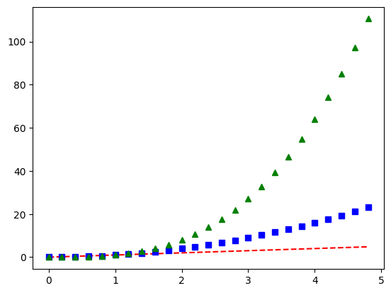

```python
import numpy as np
import matplotlib.pyplot as plt

# Chia đoạn [0, 5) thành các bước 0.2
t = np.arange(0., 5., 0.2)

# Vẽ 3 đường:
# - màu đỏ, nét đứt: y = x
# - màu xanh dương, marker hình vuông: y = x^2
# - màu xanh lá, marker tam giác: y = x^3
plt.plot(t, t, 'r--',   # red, dashed
         t, t**2, 'bs', # blue, square marker
         t, t**3, 'g^') # green, triangle marker

# Hiển thị biểu đồ
plt.show()
```

### Biểu đồ dạng cột (bar plot)

#### Biểu đồ dạng cột chiều đứng

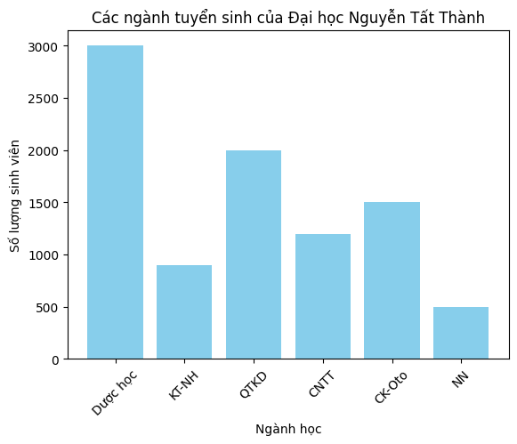

```python
import matplotlib.pyplot as plt

# Dữ liệu tuyển sinh
D = {
    'Dược học': 3000,
    'KT-NH': 900,
    'QTKD': 2000,
    'CNTT': 1200,
    'CK-Oto': 1500,
    'NN': 500
}

# Vẽ biểu đồ cột
plt.bar(range(len(D)), D.values(), align='center', color='skyblue')

# Gắn nhãn trục X
plt.xticks(range(len(D)), D.keys(), rotation=45)

# Thêm tiêu đề
plt.title('Các ngành tuyển sinh của Đại học Nguyễn Tất Thành')

# Thêm nhãn trục
plt.xlabel('Ngành học')
plt.ylabel('Số lượng sinh viên')

# Hiển thị biểu đồ
plt.show()
```

#### Biểu đồ dạng cột chiều ngang

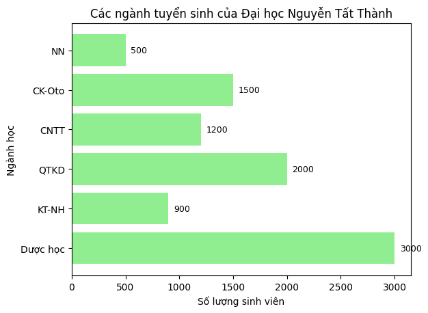

```python
import matplotlib.pyplot as plt

# Dữ liệu
D = {
    'Dược học': 3000,
    'KT-NH': 900,
    'QTKD': 2000,
    'CNTT': 1200,
    'CK-Oto': 1500,
    'NN': 500
}

# Vẽ biểu đồ cột ngang
plt.barh(list(D.keys()), list(D.values()), color='lightgreen')

# Tiêu đề và nhãn trục
plt.title('Các ngành tuyển sinh của Đại học Nguyễn Tất Thành')
plt.xlabel('Số lượng sinh viên')
plt.ylabel('Ngành học')

# Hiển thị giá trị bên cạnh cột
for i, v in enumerate(D.values()):
    plt.text(v + 50, i, str(v), va='center', fontsize=9)

plt.show()
```

#### Có thể ghép 2 biểu đồ

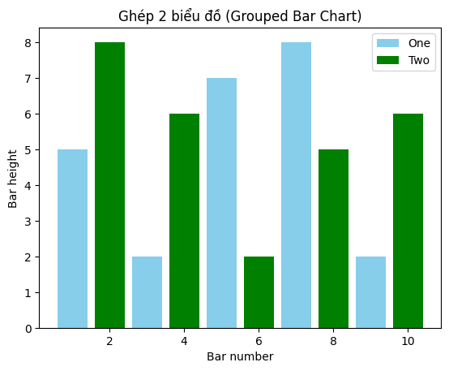

```python
import matplotlib.pyplot as plt

# Dữ liệu
x1 = [1, 3, 5, 7, 9]
y1 = [5, 2, 7, 8, 2]

x2 = [2, 4, 6, 8, 10]
y2 = [8, 6, 2, 5, 6]

# Vẽ 2 biểu đồ cột cạnh nhau
plt.bar(x1, y1, label="One", color="skyblue")
plt.bar(x2, y2, label="Two", color="green")

# Thêm tiêu đề, nhãn trục, và legend
plt.xlabel("Bar number")
plt.ylabel("Bar height")
plt.title("Ghép 2 biểu đồ (Grouped Bar Chart)")
plt.legend()

# Hiển thị biểu đồ
plt.show()
```